# Pacote Shiny

André, Bruno, Caio, Gabriel e João Gabriel

# Programação Reativa

## O que é reatividade?

Resumidamente, reatividade em programação é o conceito que torna possível a interação dinâmcica do usuário com o programa, no qual o que é efetivamente executado e exibido se baseia no acompanhamento das mudanças de determinados valores. Por exemplo, se um determinado input muda, um novo cálculo deve ser executado e um novo output gerado.

## Programação Reativa

### Como funciona a reatividade em apps Shiny?

A reatividade se baseia em uma paradigma diferente de programção, chamado de declarativo. No Shiny, declaramos dentro da função `server()` quando e quais códigos devem ser executados a depender de cada nova situação. As relações de dependência entre input e output e os consequentes fluxos de execução nesses casos são definidadas e representadas através de um diagrama de reatividade.

## Programação Reativa

### Diagrama de Reatividade

exemplo:

```r
# ui
ui <- fluidPage(
  selectInput(
    inputId = "variavel_A",
    label = "Variável A",
    choices = names(mtcars)
  ),
  plotOutput(outputId = "histograma_A"),
  selectInput(
    inputId = "variavel_B",
    label = "Variável B",
    choices = names(mtcars)
  ),
  plotOutput(outputId = "histograma_B")
)
```

fonte: https://programando-em-shiny.curso-r.com

## Programação Reativa

### Diagrama de Reatividade

exemplo:

```r
# server
server <- function(input, output, session) {
  output$histograma_A <- renderPlot({
    print("Gerando histograma A...")
    hist(mtcars[[input$variavel_A]], main = "Histograma A")
  })
  output$histograma_B <- renderPlot({
    print("Gerando histograma B...")
    hist(mtcars[[input$variavel_B]], main = "Histograma B")
  })
}

# app
shinyApp(ui, server)
```

fonte: https://programando-em-shiny.curso-r.com

## Programação Reativa

### Diagrama de Reatividade

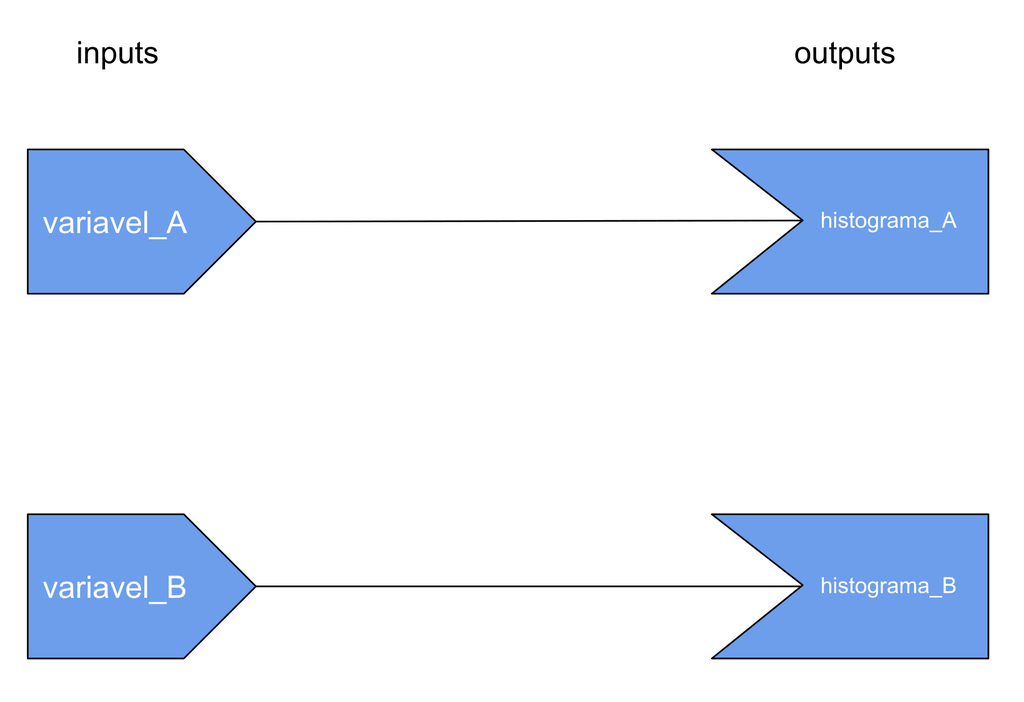

diagrama de reatividade do exemplo

fonte: https://programando-em-shiny.curso-r.com

## Programação Reativa

### Valores Reativos e Funções Observadoras

Para um app Shiny funcionar corretamente, é necessário que o diagrama de reatividade seja definido adequadamente na função `server()`. E para isso, alguns princípios devem ser observados. O primeiro deles é o seguinte: o diagrama de reatividade deve começar em um **valor reativo** e terminar em uma **função observadora**

fonte: https://programando-em-shiny.curso-r.com

## Programação Reativa

### Valores Reativos e Funções Observadoras

**valores reativos** são objetos que ativam a reatividade a partir das mudanças em seus valores. O principal exemplo de valor reativo são os próprios objetos do `input`.

**funções observadoras** são funções que acompanham as mudanças no valores reativos e executam algo diferente a partir delas. O principal exemplo de função reativas são as funções da famílias `render*()`.

fonte: https://programando-em-shiny.curso-r.com

## Programação Reativa

### Expressões Reativas

**Expressões Reativas** são objetos especiais muito importantes que atuam como valor reativo e função observadora ao mesmo tempo. São utilizadas em situações onde um valor reativo utilizado dentro de uma função observadora depende outro valor reativo.

fonte: https://programando-em-shiny.curso-r.com

## Programação Reativa

### Expressões Reativas

Sua utilidade se torna mais claro quando levamos em consideração um segundo princípio importante da reatividade no shiny: **valores e expressões reativas só podem ser lidas dentro de um contexto reativo.**

Ou seja, em um caso onde precisemos criar uma variável que dependa de um input, mas que sirva para ativar a reatividade em outputs diferentes, precisamos de uma expressão reativa, por exemplo.

fonte: https://programando-em-shiny.curso-r.com

## Programação Reativa

### Expressões Reativas

exemplo:

Imagine uma aplicação Shiny que simule o lançar de um dado simples de 6 faces. Queremos que o usário insira o número de lançamentos (tamanho da amostra) desejado e que a partir desse número seja exibido um gráfico de barras com o quantidade de aparições de cada número (distribuição observada) e um frase informando qual valor mais apareceu.

fonte: https://programando-em-shiny.curso-r.com

## Programação Reativa

### Expressões Reativas

exemplo - primeira abordagem:

```r
ui <- fluidPage(
  "INCRÍVEL DADO",
  sliderInput(
    inputId = "tamanho",
    label = "Selecione o número de lançamentos",
    min = 1,
    max = 1000,
    value = 500
  ),
  plotOutput(outputId = "distribuicao"),
  textOutput(outputId = "frase")
)
```

fonte: https://programando-em-shiny.curso-r.com

## Programação Reativa

### Expressões Reativas

exemplo - primeira abordagem:

```r
server <- function(input, output, session) {
  lancamentos <- sample(1:6, input$tamanho, replace = TRUE)

  output$distribuicao <- renderPlot({
    lancamentos |>
      table() |>
      barplot()
  })
  output$frase <- renderText({
    contagem <- table(lancamentos)
    mais_freq <- names(contagem[which.max(contagem)])
    num_ap <- contagem[mais_freq]
    paste("o valor mais sorteado foi o", mais_freq, "com ", num_ap, "aparições")
  })
}
shinyApp(ui, server)
```

fonte: https://programando-em-shiny.curso-r.com

## Programação Reativa

### Expressões Reativas

Justamente porque não seguimos o segundo princípio, e tentamos acessar o valor reativo `input$tamanho` dentro da variável comum `lancamentos`.

**Qual é abordagem correta?**

Podemos resolver criando o objeto `lancamentos` como uma expressão reativa através da função observadora `reactive()`.

fonte: https://programando-em-shiny.curso-r.com

## Programação Reativa

### Expressões Reativas

exemplo - abordagem adequada

Dentro de `server()`, ao invés de:

```r
lancamentos <- sample(1:6, input$tamanho, replace = TRUE)
```

Fazemos:

```r
lancamentos <- reactive({
    sample(1:6, input$tamanho, replace = TRUE)
  })

## Observação: devemos utilizar () ao lado do nome (como uma função)
## para acessar as expressões reativas criadas
```

## Programação Reativa

### Funções Para Expressões Reativas

#### `reactive()`

A função `reactive()` cria uma expressão reativa que observa todos os valores reativos presentes dentro de seu código.

No exemplo anterior, criamos a expressão reativa `lancamentos` cujo valor é recalculado sempre que o valor reativo `input$tamanho` mudar, e utilizamos seu valor chamando `lancamentos()` dentro das funções observadoras `renderPlot()` e `renderText()`.

fonte: https://programando-em-shiny.curso-r.com

## Programação Reativa

### Funções Para Expressões Reativas

#### `eventReactive()`

A função `eventReactive()` é similar, mas observa mudanças em apenas um valor reativo, especificado na chamada da própria função.

Geralmente é utilzada quando queremos atrasar (delay) a ativação da função observadora.

Um caso comum de uso é quando temos um botão na UI, criado com a função `actionButton()`, por exemplo.

## Programação Reativa

### Funções Para Expressões Reativas

#### `eventReactive()`

Podemos utilizar essa ideia para incrementar o nosso exemplo anterior, de tal forma que os outputs só serão gerados caso o botão seja clicado, independente se os valores de `input$tamanho` mudarem.

Adicionamos a função `actionButton()` da seguinte maneira:

```r
actionButton(inputId = "botao", label = "Simular")
```

fonte: https://programando-em-shiny.curso-r.com

## Programação Reativa

### Funções Para Expressões Reativas

#### `eventReactive()`

E atribuímos ao objeto `lancamentos` dentro do `server()` a função `eventReactive()` tendo `input$botao` como primeiro argumento:

```r
lancamentos <- eventReactive(input$botao, {
    sample(1:6, input$tamanho, replace = TRUE)
  })
```

fonte: https://programando-em-shiny.curso-r.com

## Programação Reativa

### Outras Funções Observadoras

#### `observe() E observeEvent()`

A funções `observe()` e `observetEvent()` tem o conceito semelhante a `reactive()` e `eventReactive()`, porém possuem uma diferença fundamental: elas não geram expressões reativas, sendo utilizadas apenas para rodar determinado código caso uma mudança em algum valor reativo aconteça. Ou seja, não podemos definir a expressão reativa `lancamentos` do exemplo anterior com elas.

fonte: https://programando-em-shiny.curso-r.com

## Programação Reativa

### Outras Funções Observadoras

#### `observe() E observeEvent()`

Geralmente são utilizadas quando queremos usar a reatividade para disparar (trigger) ações que não estão ligadas à geração de outputs, como o registro de informações em bases de dados ou o envio de e-mails, por exemplo.

fonte: https://programando-em-shiny.curso-r.com

## Programação Reativa

### Outras Funções Importantes

#### `isolate()`

Utilizada para isolar um valor reativo específico entre vários, de tal forma que se **apenas** ele for alterado nenhuma reatividade é disparada.

fonte: https://shiny.posit.co/r/getstarted/build-an-app/reactivity-essentials/stop-trigger-delay.html

## Programação Reativa

### Outras Funções Importantes

#### `reactiveVal() E reactiveValues()`

Utilizada para gerar apenas um (`reactiveVal`) ou mais (`reactiveValues`) valores reativos mutáveis, diferentes do objetos do `input`, que são imutáveis.

Pode ser usada em alguns casos quando queremos controlar valores reativos dentro do server(), e renderizar mudanças na UI a partir deles.

fonte: https://programando-em-shiny.curso-r.com

## Programação Reativa

### Outras Funções Importantes

#### `req() E validate()`

Utilizada para validar valores reativos. Nesse contexto **inválido** indica um objeto:

```
• FALSE
• NULL
• "", uma string vazia
• Um vetor vazio
• Um vetor que contenha apenas NA
• Um vetor lógico que contenha apenas FALSE ou NA
• Um objeto com classe try-error
• Um valor reativo que represente um actionButton() que ainda não foi clicado
```

fonte: https://programando-em-shiny.curso-r.com

## Programação Reativa

### Outras Funções Importantes

#### `req() E validate()`

A função `req()` retorna um erro silencioso. Com o qual podemos definir que o `server()` e a `ui()` devem manter as coisas como estavam antes.

Já a função `validate()` permite customizar o erro retornado.

fonte: https://programando-em-shiny.curso-r.com

[figure not shown]